# IODS course project

Ricarda Duerst

# Introduction to Open Data Science - Course Project

# About the project

In this course diary I will update my progress with the online course *Introduction to Open Data Science*. The course focuses on understanding the possibilities of **open science, open data, and open research tools** using RStudio, GitHub and R Markdown. We will also visualize and analyze data sets with some fairly advanced statistical methods. As a first step, we created a GitHub repository for the course: https://github.com/RicardaDuerst/IODS-project.  
I am participating in this course as part of my doctoral research at the University of Helsinki. I have worked happily with R and RStudio since years. However, my GitHub account was never really used since its creation. Therefore, I hope to gain better understanding of GitHub and version control as well as R Markdown files during this course. My goal is to use version control with Git for all my research projects in the future and publish some projects on my GitHub page https://github.com/RicardaDuerst.

# Regression and model validation

*This week’s topic is simple regression analysis with linear models and method validation. What follows is a short report on my results for Exercise 2 of the IODS course.*

The data used for this analysis is from the International Survey of Approaches to Learning, made possible by Teacher’s Academy funding for Kimmo Vehkalahti. Data were collected from 3.12.2014 to 10.01.2015 from students taking part in a statistics course. I created a subset of the data including variables on demographic characteristics and learning attitudes. The main interest of this analysis is the relationship between student’s learning approaches and exam outcomes.

```r
# read in previously prepared data
data <- read.table("data\\learning2014.csv", header = T, sep = ",")
# the first six rows of the data set
head(data)
```

```
##   gender Age Attitude     deep  stra     surf Points
## 1      F  53       37 3.583333 3.375 2.583333     25
## 2      M  55       31 2.916667 2.750 3.166667     12
## 3      F  49       25 3.500000 3.625 2.250000     24
## 4      M  53       35 3.500000 3.125 2.250000     10
## 5      M  49       37 3.666667 3.625 2.833333     22
## 6      F  38       38 4.750000 3.625 2.416667     21
```

My data set contains 166 observations and seven variables. Those being: **gender** (coded as a factor with the two levels male (M) and female (F)), **age** (in years, derived from the date of birth), **Points** (the student’s exam points in a statistics exam), a combination variable that measures the student’s general attitude toward statistics (**Attitude**), as well as three combination variables assessing different learning approaches:  
- Deep approach: the student wants to maximize their understanding and has a true commitment to learning (**deep**)  
- Surface approach: the student memorizes without understanding and lacks personal engagement in the learning process (**surf**)  
- Strategic approach: the student applies a strategy that maximizes the chance of achieving the highest possible grade (**stra**).

```r
# row and column numbers of the data set
dim(data)
```

```
## [1] 166   7
```

All combination variables have been scaled to their original scales by taking the mean. The three learning approaches are coded numerically while **Attitude**, **Points**, and **age** are integer variables. Further, I excluded observations where the exam points variable is zero, meaning that the student did not attend the exam.

```r
# structure of the data set and it's variables
str(data)
```

```
## 'data.frame':    166 obs. of  7 variables:
##  $ gender  : Factor w/ 2 levels "F","M": 1 2 1 2 2 1 2 1 2 1 ...
##  $ Age     : int  53 55 49 53 49 38 50 37 37 42 ...
##  $ Attitude: int  37 31 25 35 37 38 35 29 38 21 ...
##  $ deep    : num  3.58 2.92 3.5 3.5 3.67 ...
##  $ stra    : num  3.38 2.75 3.62 3.12 3.62 ...
##  $ surf    : num  2.58 3.17 2.25 2.25 2.83 ...
##  $ Points  : int  25 12 24 10 22 21 21 31 24 26 ...
```

```r
# load necessary libraries
library(ggplot2)
library(GGally)
```

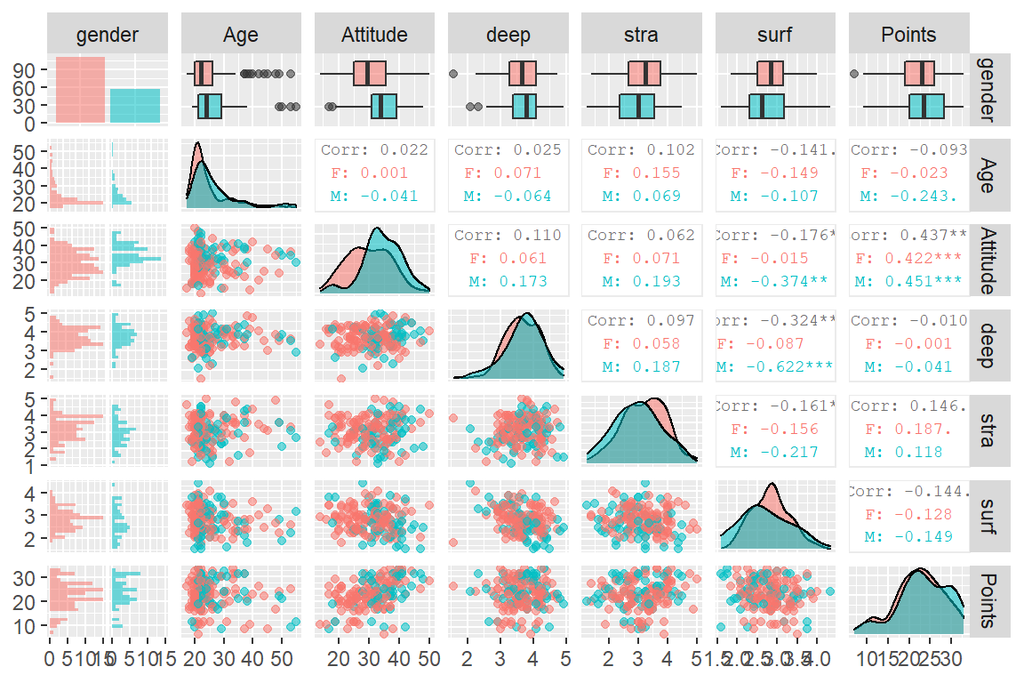

```r
# plot
ggpairs(data, mapping = aes(col = gender, alpha = 0.3), lower = list(combo = wrap("facethist", bins = 20)),
        upper = list(continuous = wrap("cor", size = 2.5)))
```

Further, I looked at summary measures for each variable. The exploration of the data shows that around 66% of the students are female and the majority of students is in it’s early to mid-20s. However, the oldest student is a 55 years old man. On average, students attending the exam scored 22.7 points.

```r
summary(data$gender)
```

```
##   F   M
## 110  56
```

```r
summary(data$Age)
```

```
##    Min. 1st Qu.  Median    Mean 3rd Qu.    Max.
##   17.00   21.00   22.00   25.51   27.00   55.00
```

```r
summary(data$Attitude)
```

```
##    Min. 1st Qu.  Median    Mean 3rd Qu.    Max.
##   14.00   26.00   32.00   31.43   37.00   50.00
```

```r
summary(data$deep)
```

```
##    Min. 1st Qu.  Median    Mean 3rd Qu.    Max.
##   1.583   3.333   3.667   3.680   4.083   4.917
```

```r
summary(data$stra)
```

```
##    Min. 1st Qu.  Median    Mean 3rd Qu.    Max.
##   1.250   2.625   3.188   3.121   3.625   5.000
```

```r
summary(data$surf)
```

```
##    Min. 1st Qu.  Median    Mean 3rd Qu.    Max.
##   1.583   2.417   2.833   2.787   3.167   4.333
```

```r
summary(data$Points)
```

```
##    Min. 1st Qu.  Median    Mean 3rd Qu.    Max.
##    7.00   19.00   23.00   22.72   27.75   33.00
```

To answer the question which of the variables have an effect on a student’s exam points, I fitted a linear regression model with **Points** as the target variable and **Attitude**, **Age**, and **stra** as the explanatory variables. I chose these variables based on the correlations from the ggpairs plot. I did not include **surf** because one of the seven classical assumptions of Ordinary Least Squares (OLS) linear regression is that the explanatory variables are independent from each other. Given the correlation between **surf** and the other two learning approaches as well as **Attitude**, this assumption would be violated if I included **surf** in the model.

```r
# linear regression model  with three explanatory variables
model1 <- lm(Points ~ Attitude + Age + stra, data = data)
```

Regarding the interpretation of the model parameters, **Attitude** and **stra** are positively and **Age** is negatively correlated with the exam points. If the measure for the general attitude toward statistics increases by one unit (more positively toward statistics), the average increase in exam points is 0.35 points, while assuming that the other variables stay constant. Further, with every year of age, the exam score decreases on average by 0.09 points. And lastly, having one unit more of an strategic learning approach increases the exam points by one point on average. However, the standard error for the **stra** coefficient is quite big compared to the others (Std. Error of 0.53 vs. 0.06 (Attitude) and 0.05 (Age)). An interpretation of the intercept would not contain any meaningful information.

```r
summary(model1)
```

```
##
## Call:
## lm(formula = Points ~ Attitude + Age + stra, data = data)
##
## Residuals:
##      Min       1Q   Median       3Q      Max
## -18.1149  -3.2003   0.3303   3.4129  10.7599
##
## Coefficients:
##             Estimate Std. Error t value Pr(>|t|)
## (Intercept) 10.89543    2.64834   4.114 6.17e-05 ***
## Attitude     0.34808    0.05622   6.191 4.72e-09 ***
## Age         -0.08822    0.05302  -1.664   0.0981 .
## stra         1.00371    0.53434   1.878   0.0621 .
## ---
## Signif. codes:  0 '***' 0.001 '**' 0.01 '*' 0.05 '.' 0.1 ' ' 1
##
## Residual standard error: 5.26 on 162 degrees of freedom
## Multiple R-squared:  0.2182, Adjusted R-squared:  0.2037
## F-statistic: 15.07 on 3 and 162 DF,  p-value: 1.07e-08
```

To validate my model I plotted three different residual diagnostics. With these plots I am able to validate four model assumptions regarding the residuals:  
- The errors are normally distributed –> *QQ-plot*  
- The errors are not correlated –> *Residuals vs. Fitted*  
- The errors have constant variance, and the size of a given error does not depend on the explanatory variables –> *Residuals vs. Fitted*.  
In addition, using the *Residuals vs. Leverage* plot, shows whetehr there single observation that have too much impact on the regression line.

The first plot shows the residuals plotted against the fitted values from the model. Because there is no visible pattern in the residuals, I think that the assumptions on error normality, error correlation, constant variance of errors as well as the independence of errors from the explanatory variables are not violated. Further, the standardized residuals adequately follow the line in the QQ-plot. Last but not least, none of the observations is having an outlying strong impact on the regression results, as shown by *Residuals vs. Leverage*.

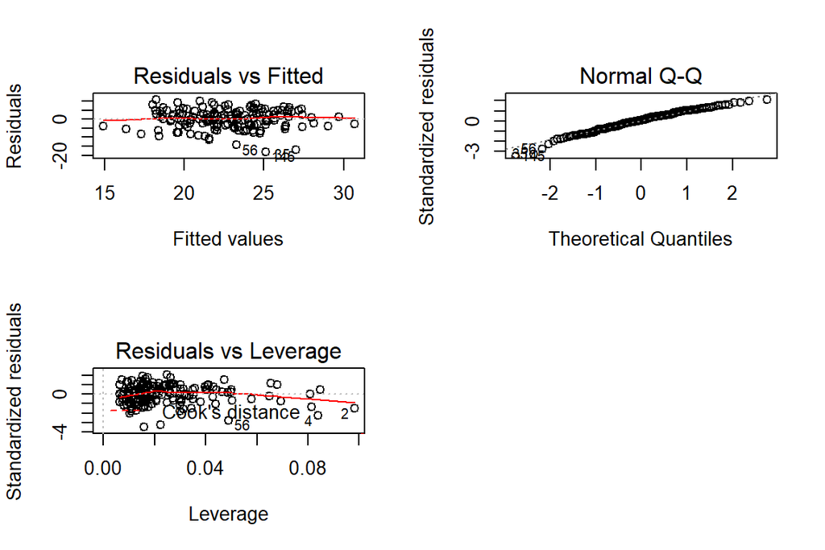

```r
par(mfrow = c(2,2))
plot(model1, which = c(1, 2, 5))
```

# Logistic Regression

*What follows is my report for the IODS course exercise 3 that focuses on performing and interpreting logistic regression analysis.*

The data used for this analysis is from the University of California’s Machine Learning Repository (Dua, D. and Graff, C. (2019). UCI Machine Learning Repository http://archive.ics.uci.edu/ml. Irvine, CA: University of California, School of Information and Computer Science). The **Student Performance Data set** (P. Cortez and A. Silva. Using Data Mining to Predict Secondary School Student Performance. In A. Brito and J. Teixeira Eds., Proceedings of 5th FUture BUsiness TEChnology Conference (FUBUTEC 2008) pp. 5-12, Porto, Portugal, April, 2008, EUROSIS, ISBN 978-9077381-39-7.http://www3.dsi.uminho.pt/pcortez/student.pdf) has information on student’s achievements in secondary education of two Portuguese schools. The data includes variables on student’s grades, demographics, social and school related features, as well as alcohol consumption. Two data sets were collected using questionnaires and address the performance in two distinct subjects: Mathematics and Portuguese language .

```r
# load necessary libraries
library(ggplot2)
library(GGally)
library(dplyr)
library(boot)
```

```r
# read in previously prepared data
alc <- read.table("data\\alc.csv", header = TRUE, sep = ",")
```

I previously performed data preparation steps to enable a logistic regression analysis. The result is a joined data set with 382 observations of students and 35 variables which can be seen in the following list. The variables contain information on student’s school outcomes (*G1*, *G2*, *G3*, *failures*), demographics (e.g. *sex*, *age*, *address*, *famsize*, *health*) and variables concerning school-related (e.g. *reason*, *studytime*, *paid*, *higher*, *absences*) and social behavior (e.g. *romantic*, *freetime*, *goout*) including alcohol consumption (*Dalc*, *Walc*).

```r
colnames(alc) # variable names
```

```
##  [1] "school"     "sex"        "age"        "address"    "famsize"
##  [6] "Pstatus"    "Medu"       "Fedu"       "Mjob"       "Fjob"
## [11] "reason"     "nursery"    "internet"   "guardian"   "traveltime"
## [16] "studytime"  "failures"   "schoolsup"  "famsup"     "paid"
## [21] "activities" "higher"     "romantic"   "famrel"     "freetime"
## [26] "goout"      "Dalc"       "Walc"       "health"     "absences"
## [31] "G1"         "G2"         "G3"         "alc_use"    "high_use"
```

```r
dim(alc) # dimension of the data set
```

```
## [1] 382  35
```

The purpose of this analysis is to study the relationship between high or low alcohol consumption and other variables of the data set. Therefore, the following adjustments have been made to the data:

- The variables not used for joining the two data sets have been combined by averaging,
- *alc_use* is the average of *Dalc* (workday alcohol consumption) and *Walc* (weekend alcohol consumption), and
- *high_use* is TRUE if *alc_use* is higher than 2 and FALSE otherwise.

I chose four variables that may have a relationship with alcohol consumption measured with *high_use*: *absences* (number of school absences), *failures* (number of past class failures), *G3* (final grade), and *goout* (going out with friends). I came up with the following personal hypotheses for the relationship of these variables with the student’s alcohol consumption:

- A higher number of school absences is associated with high alcohol consumption,
- a higher number of failed classes in the past is associated with a high alcohol consumption,
- a higher final grade is associated with low alcohol consumption, and
- going out with friends more often is associated with high alcohol consumption.

To make the analysis easier, I subset the data into a new data set only containing the variables I am interested in.

```r
# subset the data set to the variables I am interested in
my_alc <- select(alc, high_use, sex, absences, G3, failures, goout)
```

To further explore the data set and the relationships between it’s variables, I used the R function *ggpairs*. The output is a correlation matrix with 36 different diagnostics and plots resulting from the combination of all six variables from the data set, separately for males (blue) and females (pink). For numerical variables, scatter plots are drawn on the left side (under the diagonal) and Pearson’s correlation coefficient is given on the right side (above the diagonal). On the diagonal, we can see the distribution of a each variable. For combinations of numerical variables with the bivariate (not numerical) variables *sex* and *high_use*, the plot provides box plots (in the rows) and histograms (in the columns). The histograms fro alcohol usage shows low consumption on the left and high consumption on the right side.

Regarding the relationships between the variables, it seems that my hypotheses are mainly reasonable: First, the histogram for school absences and alcohol consumption points towards a tendency that students with high alcohol consumption have more school absences than the ones with low alcohol consumption. Generally, most students of both sexes have a low number of school absences. The distribution is heavily right-skewed. However, regarding my second hypothesis, there is no visible relationship between the number of failed classes and alcohol consumption. Most students did not fail classes, though. Finally, a higher final grade and going out with friends less often seem to be associated with low alcohol consumption, as seen from the histograms. Further, there are some strong correlations between other variables: For both sexes, there is a strong negative relationship between a higher final grade and the number of failed classes, which is not surprising. Only for males, there are correlations of the variables *absences*, *G3*, and *failures* with *goout*. Going out with friends more often is associated with more school absences, a lower final grade, and more failed classes.

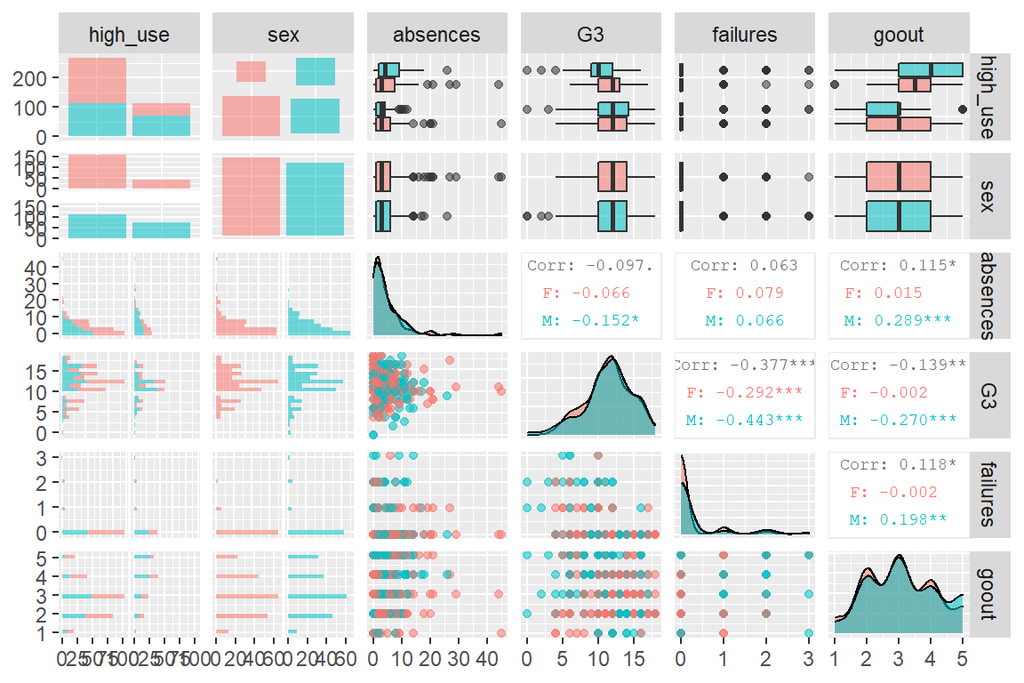

```r
# plot
ggpairs(my_alc, mapping = aes(col = sex, alpha = 0.3), lower = list(combo = wrap("facethist", bins = 20)),
        upper = list(continuous = wrap("cor", size = 2.5)))
```

For the regression analysis, I start with a logistic regression model on the bivariate variable for alcohol consumption (*high_use*) including all of my chosen variables as explanatory variables. The z-test for the model coefficients shows us that the final grade (*G3*) is not significantly associated with the probability for high alcohol consumption. However, going out with friends (*goout*) and the number of school absences (*absences*) are highly significant predictors of the probability of high alcohol consumption. The number of failed classes (*failures*) is a less strong predictor and considering the typical significance level of 5%, it is not statistically significant.

```r
my_model <- glm(high_use ~ failures + absences + goout + G3, data = my_alc, family = "binomial")
summary(my_model)
```

```
##
## Call:
## glm(formula = high_use ~ failures + absences + goout + G3, family = "binomial",
##     data = my_alc)
##
## Deviance Residuals:
##     Min       1Q   Median       3Q      Max
## -1.9179  -0.7353  -0.5704   0.9154   2.3634
##
## Coefficients:
##             Estimate Std. Error z value Pr(>|z|)
## (Intercept) -3.35645    0.67989  -4.937 7.94e-07 ***
## failures     0.36987    0.22027   1.679 0.093127 .
## absences     0.07464    0.02211   3.377 0.000734 ***
## goout        0.70604    0.11785   5.991 2.09e-09 ***
## G3          -0.02285    0.04103  -0.557 0.577493
## ---
## Signif. codes:  0 '***' 0.001 '**' 0.01 '*' 0.05 '.' 0.1 ' ' 1
##
## (Dispersion parameter for binomial family taken to be 1)
##
##     Null deviance: 465.68  on 381  degrees of freedom
## Residual deviance: 398.09  on 377  degrees of freedom
## AIC: 408.09
##
## Number of Fisher Scoring iterations: 4
```

I calculated the Odds Ratios of the coefficients and their 95% confidence intervals (width of confidence interval) to interpret the coefficients more easily. The confidence intervals for the final grade and the failures include 1. This confirms the statistically non-significance of these variables as predictors for the target variable. The interpretation of the significant coefficient’s Odds Ratios is as follows: With one more school absence, the odds of having high alcohol consumption are approximately 1.1 times higher and with one more unit of going out with friends, the odds for having high alcohol consumption are approximately twice as high.

```r
# compute odds ratios (OR)
OR <- coef(my_model) %>% exp()
# compute confidence intervals (CI)
CI <- confint(my_model) %>% exp()
# print out the odds ratios with their confidence intervals
cbind(OR, CI)
```

```
##                    OR       2.5 %    97.5 %
## (Intercept) 0.0348588 0.008760115 0.1267671
## failures    1.4475448 0.940910339 2.2401749
## absences    1.0774998 1.033230619 1.1280422
## goout       2.0259463 1.616849187 2.5689360
## G3          0.9774057 0.901971337 1.0598132
```

To build a more powerful model, I decided to exclude the non-significant variables on-by-one, starting with the final grade. In this second model, the previously unimportant variable *failures* becomes statistically significant, as indicated in the summary of the model. This is most likely due to the strong relationship between the variables. As a result, I will keep the number of failed classes in the model. Further, this action is justified by the smaller AIC value of my second model.

```r
my_model_2 <- glm(high_use ~ failures + absences + goout, data = my_alc, family = "binomial")
summary(my_model_2)
```

```
##
## Call:
## glm(formula = high_use ~ failures + absences + goout, family = "binomial",
##     data = my_alc)
##
## Deviance Residuals:
##     Min       1Q   Median       3Q      Max
## -1.8774  -0.7465  -0.5601   0.9090   2.3865
##
## Coefficients:
##             Estimate Std. Error z value Pr(>|z|)
## (Intercept) -3.65199    0.43417  -8.411  < 2e-16 ***
## failures     0.41507    0.20508   2.024  0.04298 *
## absences     0.07547    0.02208   3.418  0.00063 ***
## goout        0.71311    0.11740   6.074 1.25e-09 ***
## ---
## Signif. codes:  0 '***' 0.001 '**' 0.01 '*' 0.05 '.' 0.1 ' ' 1
##
## (Dispersion parameter for binomial family taken to be 1)
##
##     Null deviance: 465.68  on 381  degrees of freedom
## Residual deviance: 398.40  on 378  degrees of freedom
## AIC: 406.4
##
## Number of Fisher Scoring iterations: 4
```

Regarding the Odds Ratios of my second model, none of the confidence intervals of the coefficient’s Odds Ratios include 1. Now, having failed one more class results in approximately 1.5 times higher odds for having high alcohol consumption. The interpretation of the Odds Ratios for absences and going out did not change. In conclusion, I am able to **not** dismiss my previously stated hypotheses regarding the positive relationship of school absences, failed classes, and going out with friens with high alcohol consumption. However, I have to dismiss my hypothesis about the relationship of the final grade with high alcohol consumption.

```r
# compute odds ratios (OR)
OR_2 <- coef(my_model_2) %>% exp()
# compute confidence intervals (CI)
CI_2 <- confint(my_model_2) %>% exp()
# print out the odds ratios with their confidence intervals
cbind(OR_2, CI_2)
```

```
##                   OR_2     2.5 %     97.5 %
## (Intercept) 0.02593937 0.0107041 0.05891273
## failures    1.51447465 1.0137625 2.27486120
## absences    1.07838996 1.0341084 1.12889344
## goout       2.04033617 1.6296451 2.58472531
```

I explored my model’s predictive power using a cross tabulation and a plot of predictions versus actual values of high alcohol consumption. The cross table shows that my model correctly predicted 246 students with observed low alcohol consumption and 45 people with high alcohol consumption. The training error (total proportion of inaccurately classified individuals) can be computed by adding the number of wrongly predict high alcohol consumption and wrongly predicted low alcohol consumption (taken from the cross table) divided by the total number of individuals. Approximately 24% of the individuals are wrongly predicted. Therefore, my model is better than the simplest guessing strategy that randomly assigns people to high or low alcohol consumption with a probability of 0.5.

```r
# predict() the probability of high_use
probs <- predict(my_model_2, type = "response")
# add the predicted probabilities to 'alc'
my_alc <- mutate(my_alc, probability = probs)
# use the probabilities to make a prediction of high_use
my_alc <- mutate(my_alc, prediction = ifelse(probability > 0.5, TRUE, FALSE))
# tabulate the target variable versus the predictions
table(high_use = my_alc$high_use, prediction = my_alc$prediction)
```

```
##         prediction
## high_use FALSE TRUE
##    FALSE   246   22
##    TRUE     69   45
```

```r
table(high_use = my_alc$high_use, prediction = my_alc$prediction) %>% prop.table %>% addmargins
```

```
##         prediction
## high_use      FALSE       TRUE        Sum
##    FALSE 0.64397906 0.05759162 0.70157068
##    TRUE  0.18062827 0.11780105 0.29842932
##    Sum   0.82460733 0.17539267 1.00000000
```

```r
# training error
(22 + 69)/382
```

```
## [1] 0.2382199
```

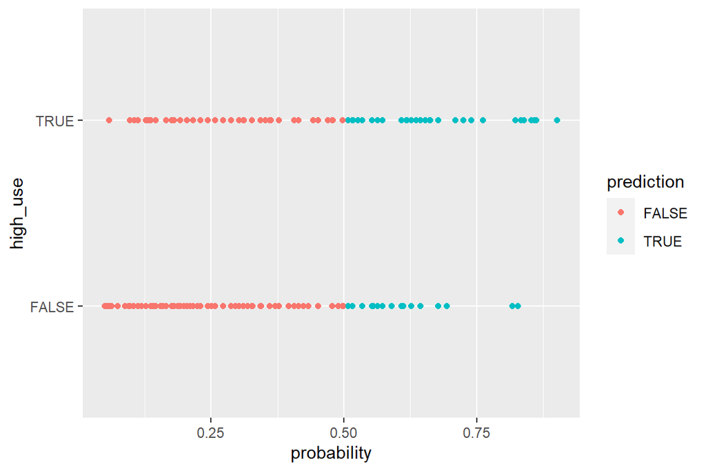

```r
# make plot with predictions and actual values
ggplot(my_alc, aes(x = probability, y = high_use, col = prediction)) + geom_point()
```

Further, I performed a 10-fold cross-validation on my model. It’s prediction error is 0.25 which is better than the model introduced in the DataCamp exercise (0.26).

```r
# define a loss function (average prediction error)
loss_func <- function(class, prob) {
  n_wrong <- abs(class - prob) > 0.5
  mean(n_wrong)
}
# compute the average number of wrong predictions in the (training) data
loss_func(my_alc$high_use, my_alc$probability)
```

```
## [1] 0.2382199
```

```r
# K-fold cross-validation
cv <- cv.glm(data = alc, cost = loss_func, glmfit = my_model_2, K = 10)
# average number of wrong predictions in the cross validation
cv$delta[1]
```

```
## [1] 0.2513089
```

# Clustering and Classification

*What follows is my report for the IODS course exercise 4 that focuses on clustering and classification*

The data used for the following analysis is from the R package *MASS* and contains information on the **Boston** (USA) **housing market**, including neighborhood variables and air pollution data. More precisely, it is aggregative census tract data in the Boston Standard Metropolitan Statistical Area (not individual observations) in 1970 (see Harrison, D. and Rubinfeld, D.L. (1978) Hedonic prices and the demand for clean air. J. Environ. Economics and Management 5, 81–102). There are 14 variables (mainly numerical) and 506 observations.

```r
# necessary libraries
library(MASS)
library(dplyr)
library(ggplot2)
library(tidyr)
```

```r
# load data from MASS package
data("Boston")
```

```r
# explore the data
str(Boston)
```

```
## 'data.frame':    506 obs. of  14 variables:
##  $ crim   : num  0.00632 0.02731 0.02729 0.03237 0.06905 ...
##  $ zn     : num  18 0 0 0 0 0 12.5 12.5 12.5 12.5 ...
##  $ indus  : num  2.31 7.07 7.07 2.18 2.18 2.18 7.87 7.87 7.87 7.87 ...
##  $ chas   : int  0 0 0 0 0 0 0 0 0 0 ...
##  $ nox    : num  0.538 0.469 0.469 0.458 0.458 0.458 0.524 0.524 0.524 0.524 ...
##  $ rm     : num  6.58 6.42 7.18 7 7.15 ...
##  $ age    : num  65.2 78.9 61.1 45.8 54.2 58.7 66.6 96.1 100 85.9 ...
##  $ dis    : num  4.09 4.97 4.97 6.06 6.06 ...
##  $ rad    : int  1 2 2 3 3 3 5 5 5 5 ...
##  $ tax    : num  296 242 242 222 222 222 311 311 311 311 ...
##  $ ptratio: num  15.3 17.8 17.8 18.7 18.7 18.7 15.2 15.2 15.2 15.2 ...
##  $ black  : num  397 397 393 395 397 ...
##  $ lstat  : num  4.98 9.14 4.03 2.94 5.33 ...
##  $ medv   : num  24 21.6 34.7 33.4 36.2 28.7 22.9 27.1 16.5 18.9 ...
```

```r
dim(Boston)
```

```
## [1] 506  14
```

To further explore the data set, I used statistical summaries of all variables and scatter plots for pairs formed from five variables. The following variables can be seen in the plot:

- *crim*: per capita crime rate by town
- *rm*: average number of rooms per dwelling
- *age*: proportion of owner-occupied units built prior to 1940
- *rad*: index of accessibility to radial highways
- *medv*: median value of owner-occupied homes in $1000s

From the plot, it is obvious that there are several relationships between the variables. There is a strong positive relationship between the number of rooms in a dwelling (*rm*) and the medium value of homes (*medv*), which is plausible. Further, there seems to be a negative connection between the crime rate (*crim*) and the medium value of homes, meaning that with higher crime rates the value of homes is decreasing in the districts. One could also conclude from the scatter plot for *age* and *medv* that there is a a negative relationship. That is, if there are more houses build prior to 1940, the median value of houses decreases. In addition, the crime rate (*crim*) increases with the proportion of older houses (*age*). There is another visible positive relationship between the index of accessibility of highways (*rad*) and the crime rate (*crim*).

```r
# show summary of variables and visualize variables and their relationships
summary(Boston)
```

```
##       crim                zn             indus            chas
##  Min.   : 0.00632   Min.   :  0.00   Min.   : 0.46   Min.   :0.00000
##  1st Qu.: 0.08204   1st Qu.:  0.00   1st Qu.: 5.19   1st Qu.:0.00000
##  Median : 0.25651   Median :  0.00   Median : 9.69   Median :0.00000
##  Mean   : 3.61352   Mean   : 11.36   Mean   :11.14   Mean   :0.06917
##  3rd Qu.: 3.67708   3rd Qu.: 12.50   3rd Qu.:18.10   3rd Qu.:0.00000
##  Max.   :88.97620   Max.   :100.00   Max.   :27.74   Max.   :1.00000
##       nox               rm             age              dis
##  Min.   :0.3850   Min.   :3.561   Min.   :  2.90   Min.   : 1.130
##  1st Qu.:0.4490   1st Qu.:5.886   1st Qu.: 45.02   1st Qu.: 2.100
##  Median :0.5380   Median :6.208   Median : 77.50   Median : 3.207
##  Mean   :0.5547   Mean   :6.285   Mean   : 68.57   Mean   : 3.795
##  3rd Qu.:0.6240   3rd Qu.:6.623   3rd Qu.: 94.08   3rd Qu.: 5.188
##  Max.   :0.8710   Max.   :8.780   Max.   :100.00   Max.   :12.127
##       rad              tax           ptratio          black
##  Min.   : 1.000   Min.   :187.0   Min.   :12.60   Min.   :  0.32
##  1st Qu.: 4.000   1st Qu.:279.0   1st Qu.:17.40   1st Qu.:375.38
##  Median : 5.000   Median :330.0   Median :19.05   Median :391.44
##  Mean   : 9.549   Mean   :408.2   Mean   :18.46   Mean   :356.67
##  3rd Qu.:24.000   3rd Qu.:666.0   3rd Qu.:20.20   3rd Qu.:396.23
##  Max.   :24.000   Max.   :711.0   Max.   :22.00   Max.   :396.90
##      lstat            medv
##  Min.   : 1.73   Min.   : 5.00
##  1st Qu.: 6.95   1st Qu.:17.02
##  Median :11.36   Median :21.20
##  Mean   :12.65   Mean   :22.53
##  3rd Qu.:16.95   3rd Qu.:25.00
##  Max.   :37.97   Max.   :50.00
```

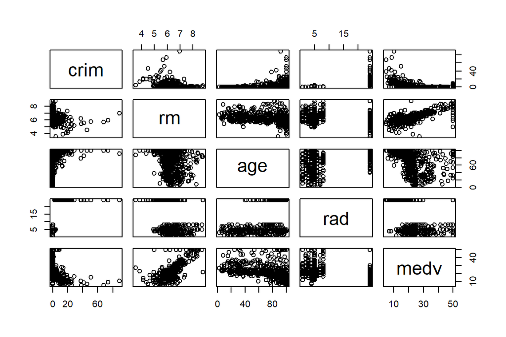

```r
pairs(Boston[c(1, 6, 7, 9, 14)])
```

For the analysis it is important to standardize (scale) the variables to achieve comparable distances. That this worked properly can be seen from the summaries of the scaled variables. Now, the mean for every variable is zero. Another data adjustment was made by creating a new categorical variable for the crime rate. The new variable *crime* was formed by binning the data into four categories using the quantiles. The old variable (*crim*) was dropped from the data set. Further, data was divided into a test set and a training set that includes 80% of the data.

```r
# standardize the variables (scale them)
boston_scaled <- scale(Boston)
summary(boston_scaled)
```

```
##       crim                 zn               indus              chas
##  Min.   :-0.419367   Min.   :-0.48724   Min.   :-1.5563   Min.   :-0.2723
##  1st Qu.:-0.410563   1st Qu.:-0.48724   1st Qu.:-0.8668   1st Qu.:-0.2723
##  Median :-0.390280   Median :-0.48724   Median :-0.2109   Median :-0.2723
##  Mean   : 0.000000   Mean   : 0.00000   Mean   : 0.0000   Mean   : 0.0000
##  3rd Qu.: 0.007389   3rd Qu.: 0.04872   3rd Qu.: 1.0150   3rd Qu.:-0.2723
##  Max.   : 9.924110   Max.   : 3.80047   Max.   : 2.4202   Max.   : 3.6648
##       nox                rm               age               dis
##  Min.   :-1.4644   Min.   :-3.8764   Min.   :-2.3331   Min.   :-1.2658
##  1st Qu.:-0.9121   1st Qu.:-0.5681   1st Qu.:-0.8366   1st Qu.:-0.8049
##  Median :-0.1441   Median :-0.1084   Median : 0.3171   Median :-0.2790
##  Mean   : 0.0000   Mean   : 0.0000   Mean   : 0.0000   Mean   : 0.0000
##  3rd Qu.: 0.5981   3rd Qu.: 0.4823   3rd Qu.: 0.9059   3rd Qu.: 0.6617
##  Max.   : 2.7296   Max.   : 3.5515   Max.   : 1.1164   Max.   : 3.9566
##       rad               tax             ptratio            black
##  Min.   :-0.9819   Min.   :-1.3127   Min.   :-2.7047   Min.   :-3.9033
##  1st Qu.:-0.6373   1st Qu.:-0.7668   1st Qu.:-0.4876   1st Qu.: 0.2049
##  Median :-0.5225   Median :-0.4642   Median : 0.2746   Median : 0.3808
##  Mean   : 0.0000   Mean   : 0.0000   Mean   : 0.0000   Mean   : 0.0000
##  3rd Qu.: 1.6596   3rd Qu.: 1.5294   3rd Qu.: 0.8058   3rd Qu.: 0.4332
##  Max.   : 1.6596   Max.   : 1.7964   Max.   : 1.6372   Max.   : 0.4406
##      lstat              medv
##  Min.   :-1.5296   Min.   :-1.9063
##  1st Qu.:-0.7986   1st Qu.:-0.5989
##  Median :-0.1811   Median :-0.1449
##  Mean   : 0.0000   Mean   : 0.0000
##  3rd Qu.: 0.6024   3rd Qu.: 0.2683
##  Max.   : 3.5453   Max.   : 2.9865
```

```r
# define data as data frame
boston_scaled <- as.data.frame(boston_scaled)

# set quantiles as breaks
bins <- quantile(boston_scaled$crim)

# create categorical variable of the crime rate (crim)
boston_scaled$crime <- cut(boston_scaled$crim, breaks = bins, include.lowest = TRUE, label = c("low", "med_low", "med_high", "high"))

# drop old crime rate variable
boston_scaled <- boston_scaled %>% dplyr::select(-crim)

# divide data in training and test data sets
n <- nrow(boston_scaled)
sample <- sample(n,  size = n * 0.8)
train <- boston_scaled[sample,]
test <- boston_scaled[-sample,]
```

```r
# fit linear discriminant analysis
fit <- lda(crime ~ ., data = train)
# summary of the LDA
fit
```

```
## Call:
## lda(crime ~ ., data = train)
##
## Prior probabilities of groups:
##       low   med_low  med_high      high
## 0.2400990 0.2524752 0.2549505 0.2524752
##
## Group means:
##                   zn      indus         chas        nox         rm        age
## low       0.92483211 -0.9087891 -0.191151743 -0.8650538  0.4289040 -0.8475432
## med_low  -0.09756268 -0.3078951 -0.002135914 -0.5500219 -0.1139536 -0.2492142
## med_high -0.37734151  0.1910114  0.109913674  0.4463536  0.2016823  0.4298524
## high     -0.48724019  1.0171096 -0.079333958  1.0450594 -0.4272221  0.8327436
##                 dis        rad        tax     ptratio       black       lstat
## low       0.8403877 -0.7036343 -0.7469984 -0.40803274  0.38027556 -0.75344300
## med_low   0.3087308 -0.5528850 -0.5187191 -0.07093611  0.31832630 -0.13556293
## med_high -0.3833238 -0.4098677 -0.3088500 -0.37544370  0.04186847 -0.04190929
## high     -0.8572752  1.6382099  1.5141140  0.78087177 -0.78374802  0.91757044
##                 medv
## low       0.51071408
## med_low   0.02500121
## med_high  0.22877711
## high     -0.69048402
##
## Coefficients of linear discriminants:
##                 LD1         LD2         LD3
## zn       0.07539717  0.69660688 -0.90963713
## indus    0.04215655 -0.23423065  0.26298457
## chas    -0.10162565 -0.02810173  0.22158474
## nox      0.31550299 -0.79392174 -1.39494194
## rm      -0.08908316 -0.17114164 -0.25925623
## age      0.31027275 -0.31860963  0.02943470
## dis     -0.01734661 -0.31858914  0.09217089
## rad      3.13332154  0.95265282 -0.05411674
## tax      0.07462207 -0.10967577  0.41946373
## ptratio  0.09553412  0.08470466 -0.28793923
## black   -0.11357562  0.03812786  0.15926017
## lstat    0.24133581 -0.20226298  0.42304809
## medv     0.19150111 -0.36311845 -0.11844658
##
## Proportion of trace:
##    LD1    LD2    LD3
## 0.9489 0.0380 0.0130
```

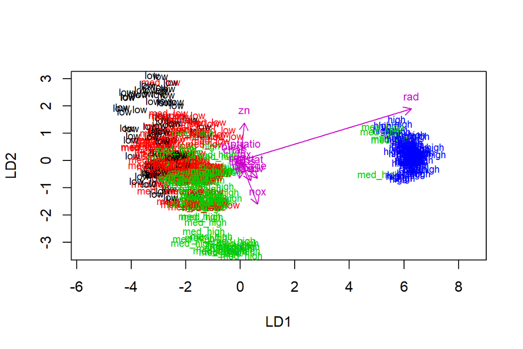

```r
# make a biplot
# function for the biplot arrows
lda.arrows <- function(x, myscale = 1, arrow_heads = 0.1, color = "magenta3", tex = 0.75, choices = c(1,2)){
  heads <- coef(x)
  arrows(x0 = 0, y0 = 0,
         x1 = myscale * heads[,choices[1]],
         y1 = myscale * heads[,choices[2]], col=color, length = arrow_heads)
  text(myscale * heads[,choices], labels = row.names(heads),
       cex = tex, col=color, pos=3)
}

# plot the lda results
plot(fit, dimen = 2, col = as.numeric(train$crime), pch = as.numeric(train$crime))
lda.arrows(fit, myscale = 2)
```

```r
# save true crime classes and then remove from them test data set
correct_classes <- test$crime
test <- dplyr::select(test, -crime)

# predict classes with LDA model
pred <- predict(fit, newdata = test)

# cross tabulate the results
table(correct = correct_classes, predicted = pred$class)
```

```
##           predicted
## correct    low med_low med_high high
##   low       18      12        0    0
##   med_low    7      15        2    0
##   med_high   1       9       12    1
##   high       0       0        0   25
```

I reloaded the data set and standardized it again to calculate the distances between the observations using the Eucledian distance. By calculating the total within sum of squares for a number of 1 to 10 clusters I searched for the optimal number of clusters. In the plot, the sudden drop of the within sum of squares indicates that the optimal number of clusters is two. Then I ran a k-means clustering algorithm on the data set with two clusters. I visualized the results using the R function *ggpairs* on the five variables from above and gave the two clusters different colors. You can clearly see that some variables effect the clustering results more than others (where there is a clear separation between the two cluster colors). These are the crime rate (*crim*) and the index of accessibility to radiant highways (*rad*).

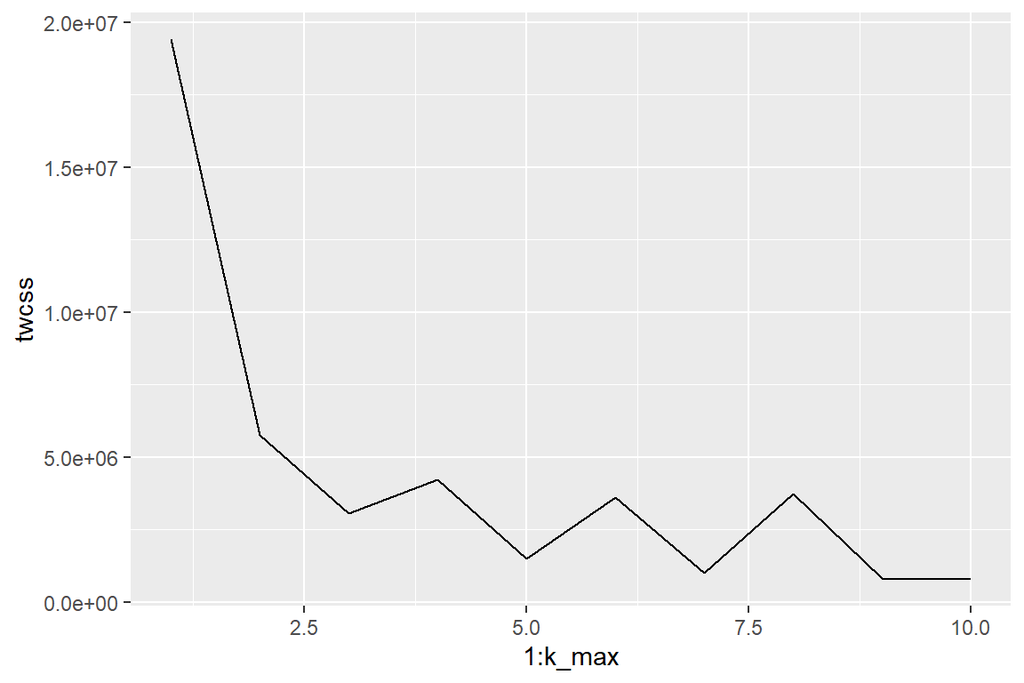

```r
# reload "Boston" data set
data('Boston')

# standardize the variables (scale them)
boston_scaled_2 <- scale(Boston)

# calculate distances between observations
dist_eu <- dist(boston_scaled_2)

# determine the best number of clusters
k_max <- 10
# calculate the total within sum of squares
twcss <- sapply(1:k_max, function(k){kmeans(Boston, k)$tot.withinss})
# visualize the results
qplot(x = 1:k_max, y = twcss, geom = 'line')
```

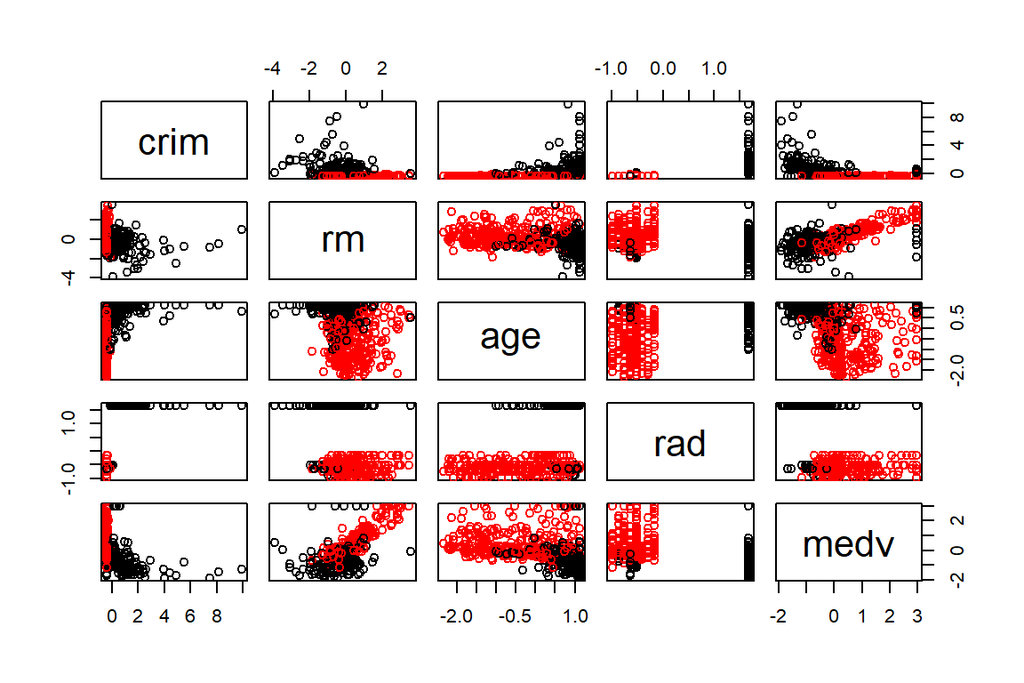

```r
# k-means clustering
km <-kmeans(boston_scaled_2, centers = 2)

# plot the Boston data set with clusters
pairs(boston_scaled_2[,c(1, 6, 7, 9, 14)], col = km$cluster)
```

# Dimensionality Reduction Techniques

*What follows is my report for the IODS course exercise 5 that focuses on principal component analysis (PCA) and multiple correspondence analysis (MCA) as dimensionality reduction techniques.*

The data used for this exercise comes from the United Nations Development Programme (see http://hdr.undp.org/en/content/human-development-index-hdi) and is a combination of two data sets containing information on the **Human Development Index (HDI) and the Gender Inequality Index (GII)** for most countries of the world.

```r
# necessary libraries
library(GGally)
library(corrplot)
library(FactoMineR)
library(dplyr)
library(tidyr)
library(gridExtra)
```

```r
# read in previously prepared data
human <- read.table("data\\human.csv", header = TRUE, sep = ",")
```

After some preparation steps, the resulting data set contains observations on 155 countries and the following 8 (mainly numerical) variables:

- *sec_edu_sexratio*: Ratio of female and male population with secondary education
- *lfp_sexratio*: Ratio of female and male labor force participation
- *exp_edu*: Expected years of schooling
- *e0*: Life expectancy at birth
- *gni*: Gross National Income
- *mmr*: Maternal Mortality Ratio
- *abr*: Adolescent birth rate
- *parlia*: Percentage of female representatives in parliament

```r
# explore structure and dimensions of the data
str(human)
```

```
## 'data.frame':    155 obs. of  8 variables:
##  $ sec_edu_sexratio: num  1.007 0.997 0.983 0.989 0.969 ...
##  $ lfp_sexratio    : num  0.891 0.819 0.825 0.884 0.829 ...
##  $ exp_edu         : num  17.5 20.2 15.8 18.7 17.9 16.5 18.6 16.5 15.9 19.2 ...
##  $ e0              : num  81.6 82.4 83 80.2 81.6 80.9 80.9 79.1 82 81.8 ...
##  $ gni             : int  64992 42261 56431 44025 45435 43919 39568 52947 42155 32689 ...
##  $ mmr             : int  4 6 6 5 6 7 9 28 11 8 ...
##  $ abr             : num  7.8 12.1 1.9 5.1 6.2 3.8 8.2 31 14.5 25.3 ...
##  $ parlia          : num  39.6 30.5 28.5 38 36.9 36.9 19.9 19.4 28.2 31.4 ...
```

```r
dim(human)
```

```
## [1] 155   8
```

To further explore the data and the relationship between its variables, I prepared visualizations of variable pairs and the correlation matrix, and statistical summaries of the variables. In the first plot, the graphs in the diagonal show the distributions of every variable in the data set. The distributions of the Gross National Income (*gni*), the maternal mortality ration (*mmr*) and the adolescent birth rate (*abr*) are heavily right-skewed. The years of expected education (*exp_edu*) are almost normally distributed and have a mean of 13 years of schooling (as seen from the variable summary). In most countries, there are more men in the labor force and there is a higher proportion of men with secondary education, compared to females. This can be seen from the graphs for *lfp_sexratio* and *sec_edu_sexratio*. In addition, the representation of the sexes in the parliaments is favoring men, in most countries (see graph for *parlia*). The life expectancy at birth is around 75 years in most countries. However, there is another local maximum at approximately 60 years. This variation in *e0* can also be seen from the interquartile range of appr. 11 years (from the variable summary). The graphs above and below the diagonal in the *ggpairs* plot and the correlation plot show (not surprisingly) the same results. There are some highly significant and very strong correlations between the variables: First, the sex ratio of secondary education is positively correlated with the years of expected education, the life expectancy, and the GNI. Further, there is a strong negative correlation with the maternal mortality rate. Second, a higher sex ratio of labor force participation is correlated with higher maternal mortality rates. Third, the expected years of schooling are also strongly correlated with life expectancy (+), GNI (+), MMR (-), and ABR (-), etc. Overall, there are significant correlations for most of the variable pairs.

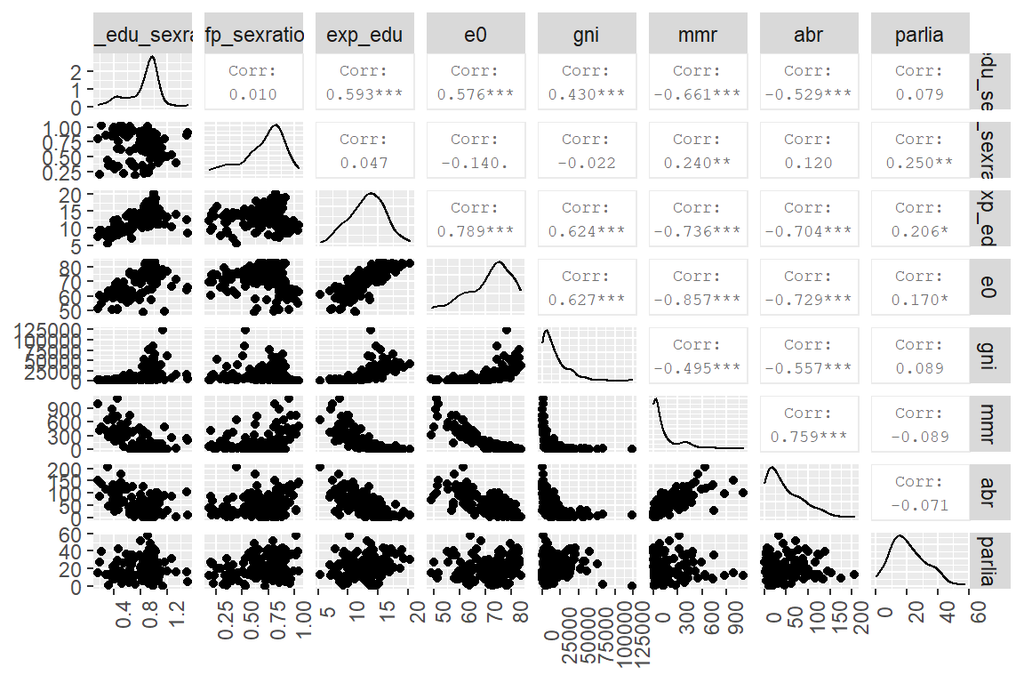

```r
# plots
ggpairs(human, upper = list(continuous = wrap("cor", size = 2.5))) +
  theme(axis.text.x = element_text(angle = 90))
```

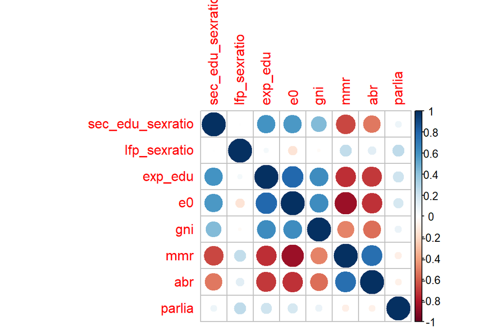

```r
corrplot(cor(human))
```

```r
# statistical summaries
summary(human)
```

```
##  sec_edu_sexratio  lfp_sexratio       exp_edu            e0
##  Min.   :0.1717   Min.   :0.1857   Min.   : 5.40   Min.   :49.00
##  1st Qu.:0.7264   1st Qu.:0.5984   1st Qu.:11.25   1st Qu.:66.30
##  Median :0.9375   Median :0.7535   Median :13.50   Median :74.20
##  Mean   :0.8529   Mean   :0.7074   Mean   :13.18   Mean   :71.65
##  3rd Qu.:0.9968   3rd Qu.:0.8535   3rd Qu.:15.20   3rd Qu.:77.25
##  Max.   :1.4967   Max.   :1.0380   Max.   :20.20   Max.   :83.50
##       gni              mmr              abr             parlia
##  Min.   :   581   Min.   :   1.0   Min.   :  0.60   Min.   : 0.00
##  1st Qu.:  4198   1st Qu.:  11.5   1st Qu.: 12.65   1st Qu.:12.40
##  Median : 12040   Median :  49.0   Median : 33.60   Median :19.30
##  Mean   : 17628   Mean   : 149.1   Mean   : 47.16   Mean   :20.91
##  3rd Qu.: 24512   3rd Qu.: 190.0   3rd Qu.: 71.95   3rd Qu.:27.95
##  Max.   :123124   Max.   :1100.0   Max.   :204.80   Max.   :57.50
```

To demonstrate the importance of standardizing the data for a principal components analysis (PCA), I fist performed a PCA on the un-standardized data. The method used for the PCA is the Singular-Value-Decomposition (SVD). From the summary of the model, we can see that the first principle component (PC1) captures more than 99.99% of the variance in the data. This can also be seen from the biplot where the observations are plotted on the coordinates of PC1 on the x-axis and PC2 on the y-axis (gray country names). Here, all arrows representing the original variables (pink), are lying on top of each other and only the variable for GNI has a visible arrow, parallel to the first principal component. This is because GNI has the largest range of values and therefore contributes most to the analysis.

```r
# PCA (with the SVD method)
pca_human <- prcomp(human)

# principal component's captured variability
summary(pca_human)
```

```
## Importance of components:
##                              PC1      PC2   PC3   PC4   PC5   PC6    PC7    PC8
## Standard deviation     1.854e+04 185.5219 25.19 11.45 3.766 1.566 0.1912 0.1591
## Proportion of Variance 9.999e-01   0.0001  0.00  0.00 0.000 0.000 0.0000 0.0000
## Cumulative Proportion  9.999e-01   1.0000  1.00  1.00 1.000 1.000 1.0000 1.0000
```

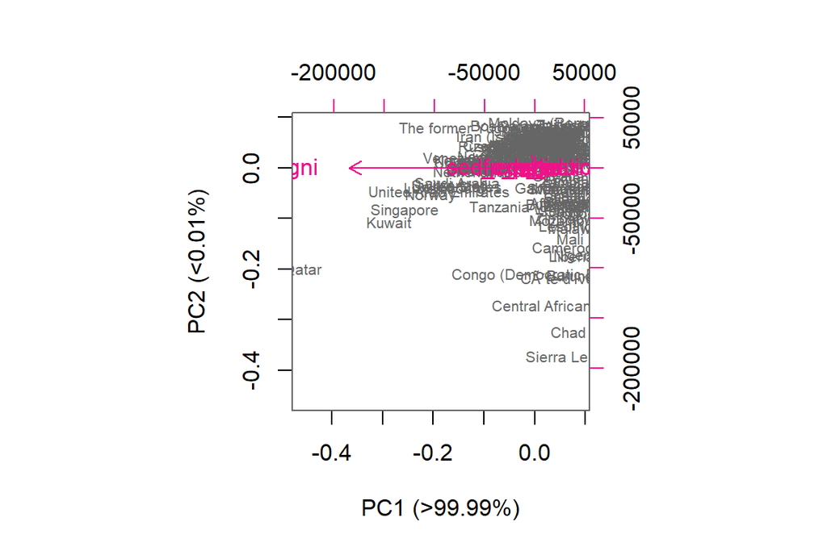

```r
# biplot
biplot(pca_human, choices = 1:2, cex = c(0.65, 1), col = c("grey40", "deeppink2"),
       xlab = "PC1 (>99.99%)", ylab = "PC2 (<0.01%)")
```

I then repeated the PCA with standardized data (all variables have a mean of 0 and a variance of 1). The results are very different from the first analysis, because now, the effects of the variables can be compared as they contributre equally to the analysis. PC1 in the second model captures 53.61% of the variance in the data and PC2 16.24%. Together, the first two principal components are able to capture almost 70% of the variance. Further, these differences can be seen in the biplot. Now, each variable is represented by a visible arrow. The arrows for the percentage of females in parliament and the labor force sex ratio are almost parallel to the second principal component. They describe the phenomenons of female empowerment and female labor force participation. The arrows that are parallel to the first principal component and are pointing towards the negative coordinates are related to the topics long life, decent standard of living, and knowledge (life expectancy at birth, GNI, and expected years of schooling). In this group there is also the arrow for the sex ratio of secondary education which also represents the topic of empowerment. Also parallel to the x-axis but pointing towards positive coordinates of PC1 are the maternal mortality ratio and the adolescent birth rate that generally measure the dimension of health. With reference to the technical notes on the Human Development Index (HDI) from the UN (http://hdr.undp.org/sites/default/files/hdr2015_technical_notes.pdf), I colored the phenomenons that are used to calculate the HDI green and the ones used to calculate the Gender Inequality Index (GII) blue (note that health is used to calculate both indices). Judging from the biplot, my personal interpretation for the first principal component is that PC1 mainly measures the HDI as there are strong correlations with knowledge, a decent standard of living, and a long and healthy live. The second principal component is representing the Gender Inequality Index as it is strongly correlated with female empowerment and female labor force participation.

```r
# standardize the data
human_std <- scale(human)

# PCA (with the SVD method)
pca_human_std <- prcomp(human_std)

# principal component's captured variability
summary(pca_human_std)
```

```
## Importance of components:
##                           PC1    PC2     PC3     PC4     PC5     PC6     PC7
## Standard deviation     2.0708 1.1397 0.87505 0.77886 0.66196 0.53631 0.45900
## Proportion of Variance 0.5361 0.1624 0.09571 0.07583 0.05477 0.03595 0.02634
## Cumulative Proportion  0.5361 0.6984 0.79413 0.86996 0.92473 0.96069 0.98702
##                            PC8
## Standard deviation     0.32224
## Proportion of Variance 0.01298
## Cumulative Proportion  1.00000
```

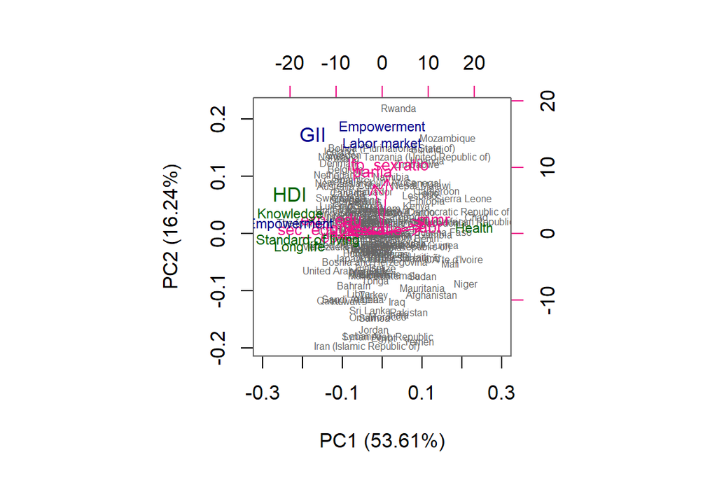

```r
# biplot
biplot(pca_human_std, choices = 1:2, cex = c(0.5, 0.8), col = c("grey40", "deeppink2"),
       xlim = c(-0.3, 0.3), xlab = "PC1 (53.61%)", ylab = "PC2 (16.24%)")
text(x = 0, y = 15, "Empowerment\nLabor market", cex = 0.7, col = "darkblue")
text(x = 20, y = 1, "Health", cex = 0.7, col = "darkgreen")
text(x = -20, y = 1.5, "Empowerment", cex = 0.7, col = "darkblue")
text(x = -20, y = 3, "Knowledge", cex = 0.7, col = "darkgreen")
text(x = -18, y = -2, "Long life", cex = 0.7, col = "darkgreen")
text(x = -16, y = -1, "Standard of living", cex = 0.7, col = "darkgreen")
text(x = -15, y = 15, "GII", col = "darkblue")
text(x = -20, y = 6, "HDI", col = "darkgreen")
```

For the multiple correspondence analysis (MCA), I used data on **tea consumption** from the *FactoMineR* package. This data set contains 36 (mainly categorical) variables on preferences and tea drinking behavior of 300 individuals. I chose the following 7 variables for the analysis of which I thought they are interesting:

- *How*: How do you drink your tea?
- *sugar*: Do you drink your tea with sugar?
- *where*: Where do you buy your tea?
- *age_Q*: Age quintile
- *sex*
- *effect.on.health*: Do you think it has an effect on your health?
- *frequency*: How often do you drink tea?

From the bar plots of the variables, you can see that most of the individuals drink their tea without anything. The second biggest group drinks it with milk. The groups of sugar and no-sugar drinkers are almost even. Tea is mainly bought in chain stores and there are slightly more female than male tea-drinkers. Further, the majority of people thinks that there is no health effect of tea drinking. Most people that answered the questionnaire drink tea daily and the age distribution is right-skewed.

```r
# load data from package FactoMineR
data(tea)

# structure and dimensions of the data
str(tea)
```

```
## 'data.frame':    300 obs. of  36 variables:
##  $ breakfast       : Factor w/ 2 levels "breakfast","Not.breakfast": 1 1 2 2 1 2 1 2 1 1 ...
##  $ tea.time        : Factor w/ 2 levels "Not.tea time",..: 1 1 2 1 1 1 2 2 2 1 ...
##  $ evening         : Factor w/ 2 levels "evening","Not.evening": 2 2 1 2 1 2 2 1 2 1 ...
##  $ lunch           : Factor w/ 2 levels "lunch","Not.lunch": 2 2 2 2 2 2 2 2 2 2 ...
##  $ dinner          : Factor w/ 2 levels "dinner","Not.dinner": 2 2 1 1 2 1 2 2 2 2 ...
##  $ always          : Factor w/ 2 levels "always","Not.always": 2 2 2 2 1 2 2 2 2 2 ...
##  $ home            : Factor w/ 2 levels "home","Not.home": 1 1 1 1 1 1 1 1 1 1 ...
##  $ work            : Factor w/ 2 levels "Not.work","work": 1 1 2 1 1 1 1 1 1 1 ...
##  $ tearoom         : Factor w/ 2 levels "Not.tearoom",..: 1 1 1 1 1 1 1 1 1 2 ...
##  $ friends         : Factor w/ 2 levels "friends","Not.friends": 2 2 1 2 2 2 1 2 2 2 ...
##  $ resto           : Factor w/ 2 levels "Not.resto","resto": 1 1 2 1 1 1 1 1 1 1 ...
##  $ pub             : Factor w/ 2 levels "Not.pub","pub": 1 1 1 1 1 1 1 1 1 1 ...
##  $ Tea             : Factor w/ 3 levels "black","Earl Grey",..: 1 1 2 2 2 2 2 1 2 1 ...
##  $ How             : Factor w/ 4 levels "alone","lemon",..: 1 3 1 1 1 1 1 3 3 1 ...
```

[output cut: 22 more lines]

```r
dim(tea)
```

```
## [1] 300  36
```

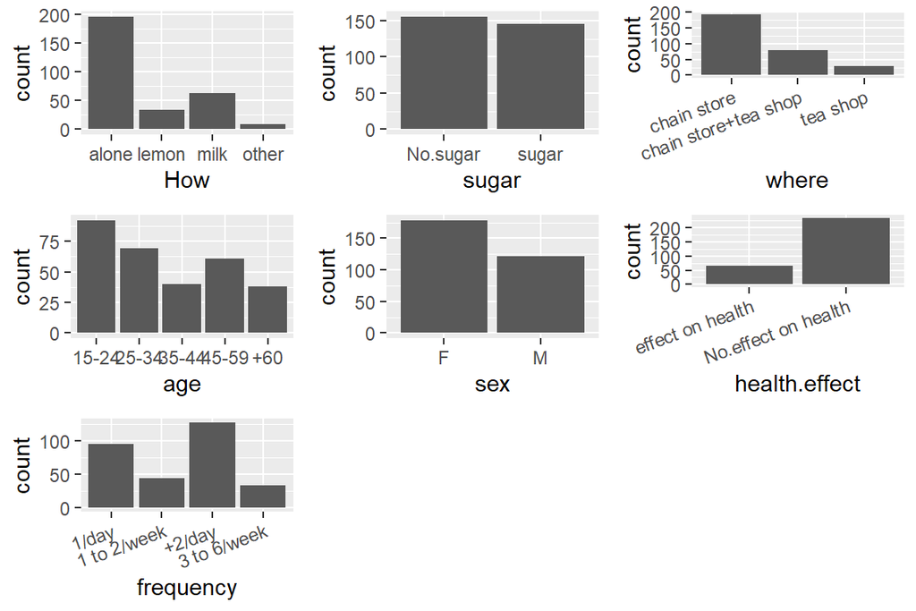

```r
# filter data to chosen variables
vars <- c("How", "sugar", "where", "age_Q", "sex", "effect.on.health", "frequency")
my_tea <- dplyr::select(tea, one_of(vars))

# rename two variables
names(my_tea)[c(4, 6)] <- c("age", "health.effect")

# visualization of my data
a <- ggplot(data = my_tea, aes(x = How)) + geom_bar(stat = "count")
b <- ggplot(data = my_tea, aes(x = sugar)) + geom_bar(stat = "count")
c <- ggplot(data = my_tea, aes(x = where)) + geom_bar(stat = "count") +
  theme(axis.text.x = element_text(angle = 20, hjust = 1))
d <- ggplot(data = my_tea, aes(x = age)) + geom_bar(stat = "count")
e <- ggplot(data = my_tea, aes(x = sex)) + geom_bar(stat = "count")
f <- ggplot(data = my_tea, aes(x = health.effect)) + geom_bar(stat = "count") +
  theme(axis.text.x = element_text(angle = 20, hjust = 1))
g <- ggplot(data = my_tea, aes(x = frequency)) + geom_bar(stat = "count") +
  theme(axis.text.x = element_text(angle = 20, hjust = 1))
grid.arrange(a, b, c, d, e, f, g, nrow = 3)
```

Then I performed a MCA on my tea data. The results can be seen in the summary of the analysis. The first dimension explains 11.22% of the variance in the data and the second dimension 9.98%. The squared correlations between the variables and the first dimension show the strongest links for the variables *frequency*, *sex*, *age*, and *sugar*. The second dimension is mainly correlated with *how*, *where*, and *age*. The biplot of the MCA (first plot) shows similarities between the categories of the variables plotted on the coordinates of the first two dimensions. From this, we can see that e.g. buying tea in the tea shop and drinking it with lemon are similar. Other similar categories are for example no sugar in the tea, drinking it twice a day, being female, and being in the age group 45-59. The second plot shows us the individuals while the third plot shows the variables (without categories) plotted on the same grid. The third plot is a visual representation of the squared correlation of the variables with the dimensions.

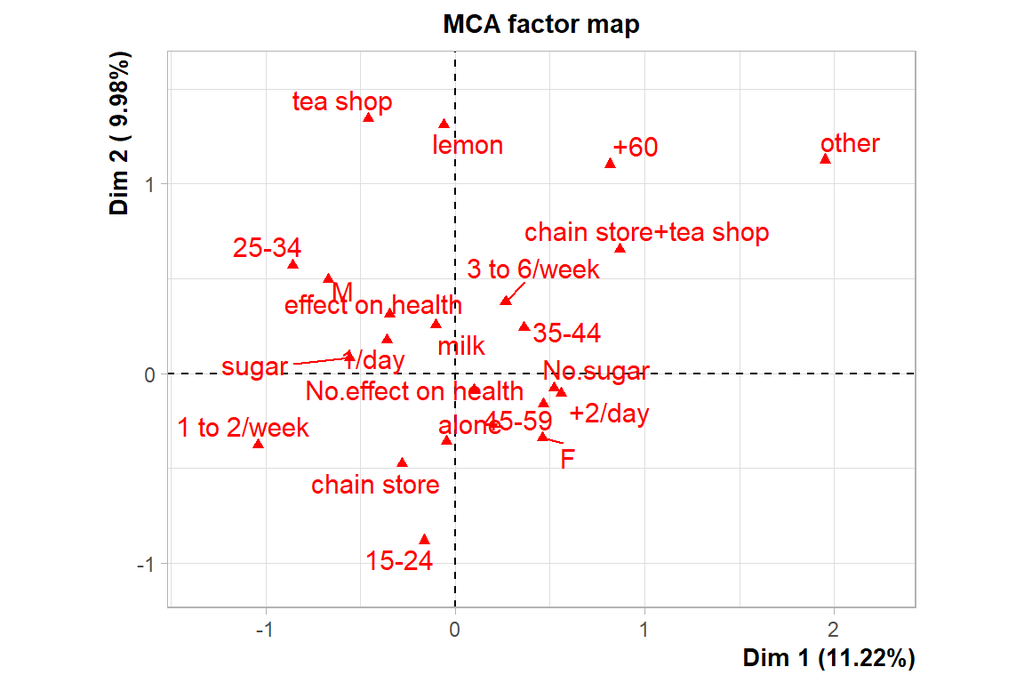

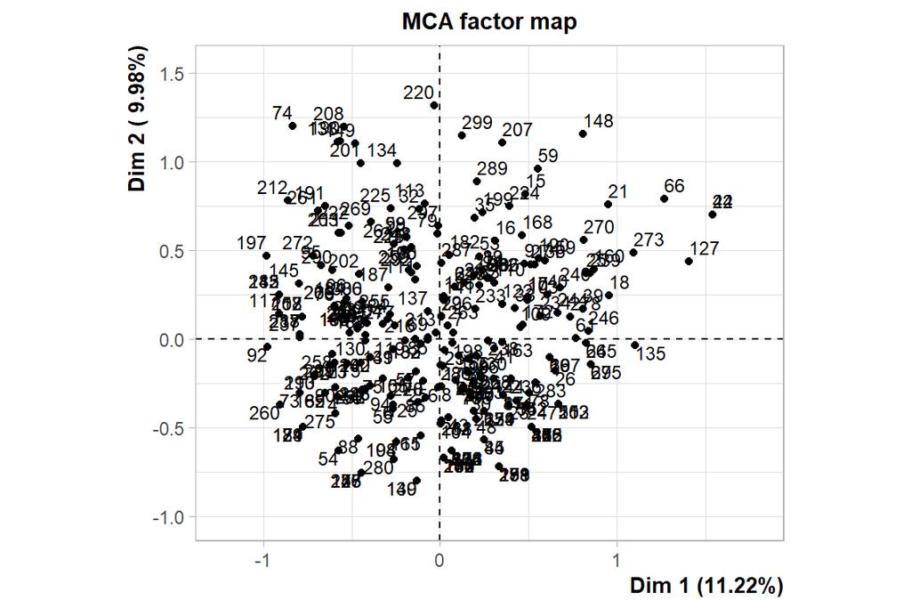

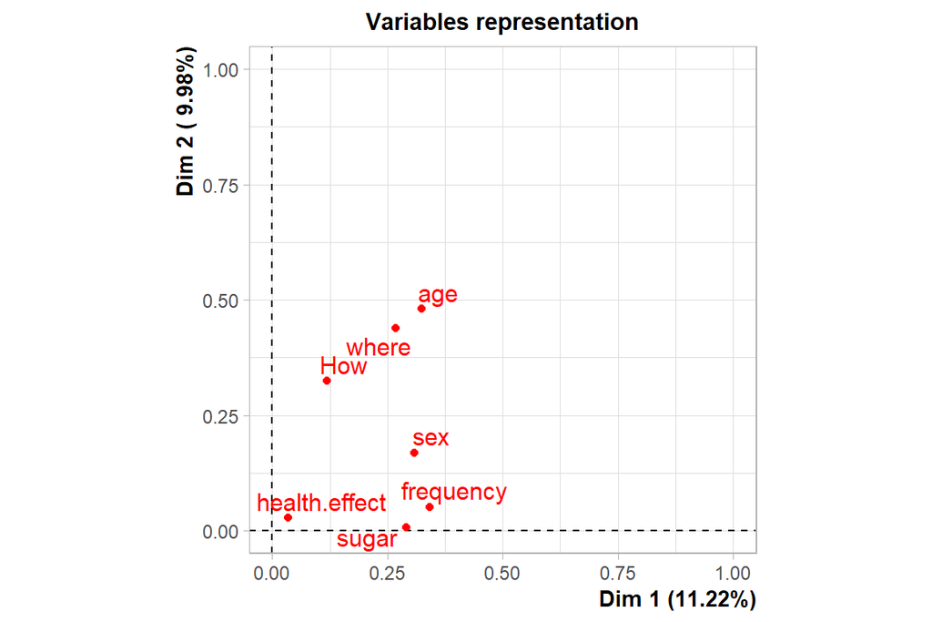

```r
# MCA on my data and plots
mca <- MCA(my_tea, graph = TRUE)
```

```r
summary(mca)
```

```
##
## Call:
## MCA(X = my_tea, graph = TRUE)
##
##
## Eigenvalues
##                        Dim.1   Dim.2   Dim.3   Dim.4   Dim.5   Dim.6   Dim.7
## Variance               0.240   0.214   0.188   0.169   0.158   0.157   0.143
## % of var.             11.216   9.979   8.769   7.869   7.351   7.324   6.660
## Cumulative % of var.  11.216  21.194  29.963  37.832  45.183  52.506  59.166
##                        Dim.8   Dim.9  Dim.10  Dim.11  Dim.12  Dim.13  Dim.14
## Variance               0.141   0.131   0.124   0.113   0.106   0.093   0.085
## % of var.              6.586   6.130   5.787   5.286   4.927   4.359   3.965
## Cumulative % of var.  65.753  71.882  77.669  82.954  87.882  92.241  96.206
##                       Dim.15
## Variance               0.081
## % of var.              3.794
## Cumulative % of var. 100.000
##
## Individuals (the 10 first)
##                         Dim.1    ctr   cos2    Dim.2    ctr   cos2    Dim.3
## 1                    | -0.424  0.249  0.100 |  0.023  0.001  0.000 |  0.037
## 2                    |  0.232  0.075  0.031 | -0.219  0.074  0.027 | -0.825
## 3                    |  0.518  0.372  0.227 | -0.495  0.382  0.207 | -0.563
## 4                    | -0.578  0.463  0.280 | -0.324  0.164  0.088 |  0.250
## 5                    |  0.189  0.049  0.027 | -0.237  0.088  0.043 | -0.622
## 6                    | -0.264  0.096  0.059 | -0.373  0.217  0.119 | -0.119
## 7                    |  0.073  0.007  0.002 |  0.035  0.002  0.000 | -0.036
## 8                    |  0.005  0.000  0.000 | -0.266  0.110  0.027 | -0.124
## 9                    |  0.477  0.315  0.093 |  0.426  0.283  0.074 | -0.113
## 10                   |  0.493  0.338  0.122 |  0.237  0.087  0.028 |  0.002
##                         ctr   cos2
## 1                     0.002  0.001 |
## 2                     1.207  0.387 |
## 3                     0.563  0.268 |
## 4                     0.111  0.052 |
## 5                     0.686  0.299 |
## 6                     0.025  0.012 |
## 7                     0.002  0.000 |
## 8                     0.027  0.006 |
```

[output cut: 21 more lines]

```
## sugar                  0.006   1.365 |   0.578  12.283   0.313   9.669 |
## chain store            0.404 -10.994 |  -0.068   0.223   0.008  -1.562 |
## chain store+tea shop   0.151   6.724 |   0.500   4.943   0.088   5.125 |
## tea shop               0.201   7.760 |  -0.866   5.708   0.083  -4.994 |
## 15-24                  0.344 -10.138 |   0.723  12.187   0.231   8.314 |
##
## Categorical variables (eta2)
##                        Dim.1 Dim.2 Dim.3
## How                  | 0.119 0.324 0.176 |
## sugar                | 0.290 0.006 0.313 |
## where                | 0.267 0.439 0.143 |
## age                  | 0.324 0.480 0.531 |
## sex                  | 0.308 0.168 0.008 |
## health.effect        | 0.034 0.028 0.041 |
## frequency            | 0.341 0.051 0.103 |
```

# Analysis of longitudinal data

*What follows is my report for the IODS course exercise 6 that focuses exploring longitudinal data as well as performing and interpreting linear mixed effects models.*

```r
# necessary libraries
library(ggplot2)
library(dplyr)
library(lme4)
```

I previously prepared two open-source data sets for this analysis that are later looked upon more deeply (data sources: https://raw.githubusercontent.com/KimmoVehkalahti/MABS/master/Examples/data/BPRS.txt and https://raw.githubusercontent.com/KimmoVehkalahti/MABS/master/Examples/data/rats.txt). The data was transformed from wide to long format. After loading the data, I had to factor two variables in each data set: the identification variable and the treatment group variable.

```r
# read in previously prepared data
bprs <- read.table("data\\bprs.csv", header = TRUE, sep = ",")
rats <- read.table("data\\rats.csv", header = TRUE, sep = ",")

# convert categorical ID and treatment group variables to factors
bprs$subject <- factor(bprs$subject)
bprs$treatment <- factor(bprs$treatment)
rats$ID <- factor(rats$ID)
rats$Group <- factor(rats$Group)
```

### Exploring the *RATS* data

In this part, I am going to explore the longitudinal nature of the *RATS* data set. It contains information of 16 rats (variable *ID*) and their weight trajectories (variable *weight*) over a period of 9 weeks (variable *time*. The rats were assigned to three different groups (variable *Group*) and were fed a different diet, respectively. The plot shows the development of each rat’s weight over the 9 weeks. The colors red, blue and green differentiate the different diet groups. For the majority of the rats, the weight is increasing over time. If it is not increasing, their weight seems to be at least steady. Further, the phenomenon of *tracking* is visible in the plot, meaning, that rats that started with a higher weight tend to have a higher weight throughout the study.

```r
# structure and dimension of the data
str(rats)
```

```
## 'data.frame':    176 obs. of  5 variables:
##  $ ID    : Factor w/ 16 levels "1","2","3","4",..: 1 2 3 4 5 6 7 8 9 10 ...
##  $ Group : Factor w/ 3 levels "1","2","3": 1 1 1 1 1 1 1 1 2 2 ...
##  $ times : Factor w/ 11 levels "WD1","WD15","WD22",..: 1 1 1 1 1 1 1 1 1 1 ...
##  $ weight: int  240 225 245 260 255 260 275 245 410 405 ...
##  $ time  : int  1 1 1 1 1 1 1 1 1 1 ...
```

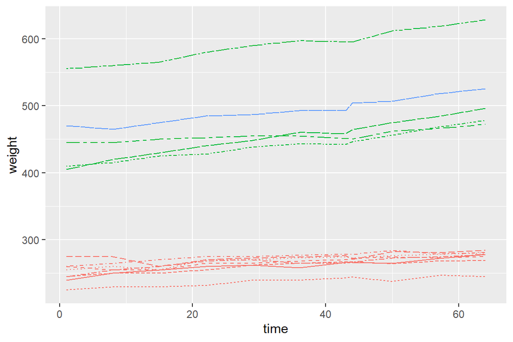

```r
# plot to explore the data
rats %>% ggplot(aes(x = time, y = weight, color = Group)) +
  geom_line(aes(linetype = ID)) +
  theme(legend.position = "none")
```

I standardized the weight variable in an attempt to see the tracking more clearly. However, in the new plot, we can see that there are rats that have a decreased (standardized) weight in the red and the green group. In addition, there are more rats that have a stable weight development. From these two plots, it is difficult to see whether there is a difference in weight gain or loss between the rats with different diets.

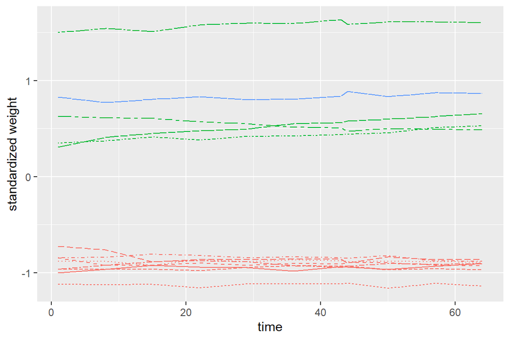

```r
# standardize the weight variable
rats <- rats %>% group_by(time) %>% mutate(std_weight = scale(weight)) %>% ungroup()

# plot with standardized weight
rats %>% ggplot(aes(x = time, y = std_weight, color = Group)) +
  geom_line(aes(linetype = ID)) +
  theme(legend.position = "none") +
  scale_y_continuous(name = "standardized weight")
```

To further explore this issue, I looked at the longitudinal data using a summary measure method. I wanted to know weather a rat’s final weight compared to the weight in the beginning of the study is different for the three groups of rats on different diets. Therefore, I chose the percentage change between the last and the first weight as a summary measure. The percentage change is defined as follows: 100 * (last weight - first weight) / first weight). After calculating the summary measure, I created a scatter plot with the percentage change for each individual rat by diet group. From this plot, we can easily see that diet group 1 consists of 8 rats while there are only 4 rats in the other two groups. The next plot shows scatter plots of the percentage change by group. We can see, that the weight of the rats with diet 2 changed more strongly throughout the study (median percentage change of 15) than the weight of rats in groups 1 (median percentage change of 9) and 3 (median percentage change of 8). In addition, there seems to be an outlier in group one with an exeptionally strong percentage change for this group.

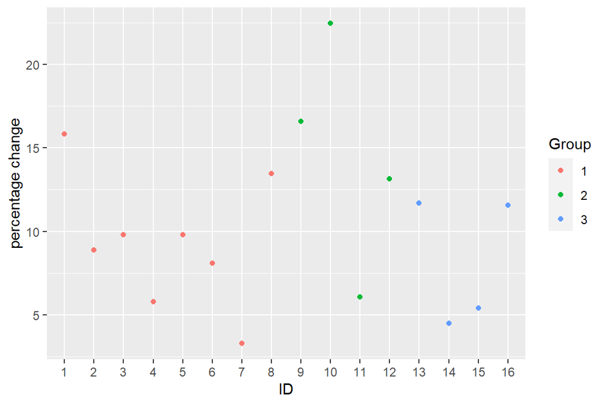

```r
# calculate the percentage change between first and last value of weight
rats <- rats %>% group_by(ID) %>% mutate(p.change = 100 * (weight[time == 64]-weight[time == 1])/weight[time == 1]) %>% ungroup()

# plot the percentage change by group of diet

# scatter plot
rats %>% ggplot(aes(x = ID, y = p.change, color = Group)) +
  geom_point() +
  scale_y_continuous(name = "percentage change")
```

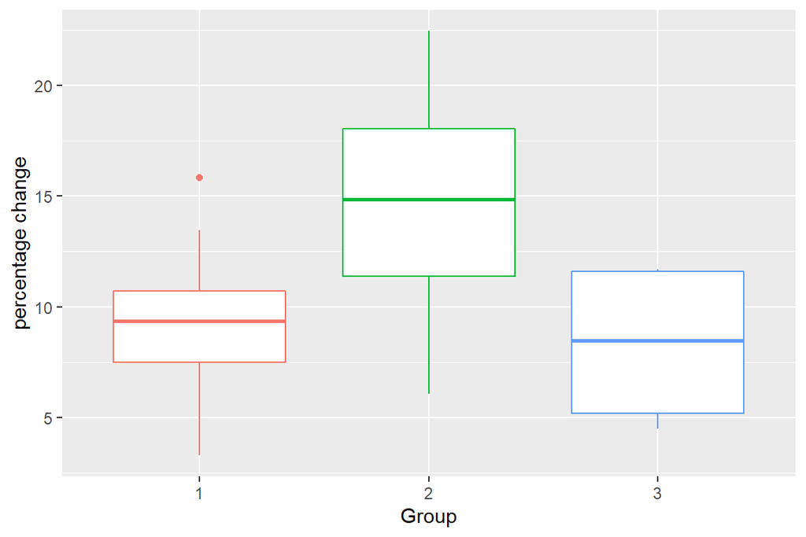

```r
# boxplot
rats %>% ggplot(aes(x = Group, y = p.change, color = Group)) +
  geom_boxplot() +
  theme(legend.position = "none") +
  scale_y_continuous(name = "percentage change")
```

To avoid any bias in the analysis because of this outlier I excluded the respective rat (*ID* = 1) from the data. After plotting the boxplots again, we can see that the general interpretation did not change. However, the difference in weight change between diet groups 2 and 1 is even more pronounced which is not surprising after excluing a high value in group one in the data. Still, the differences in weight development for rats in group 1 and group 3 does not differ much.

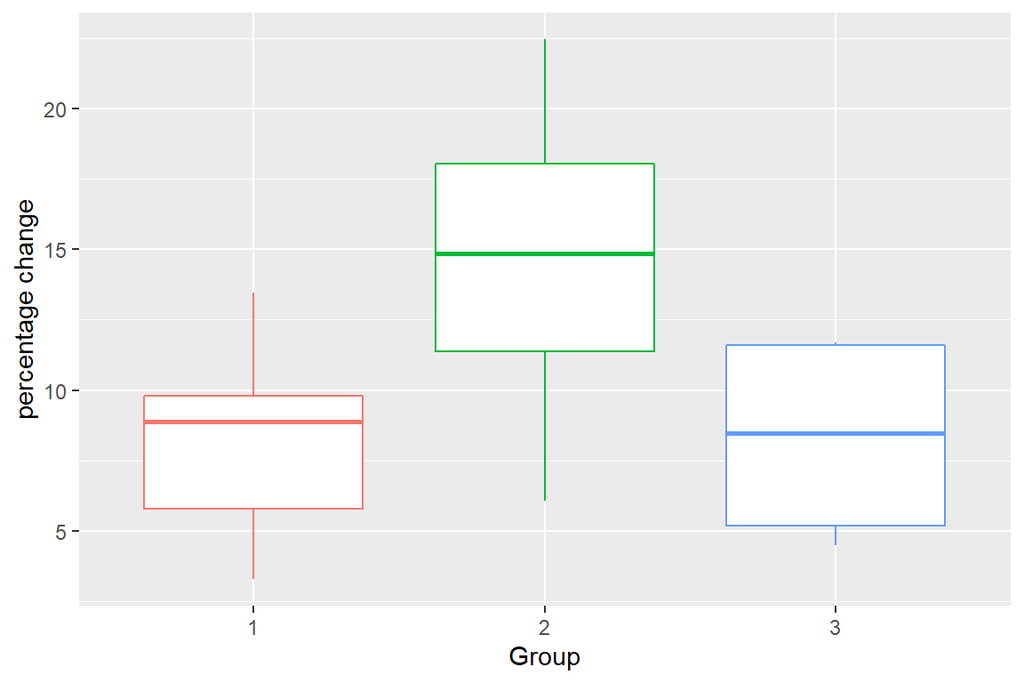

```r
# remove outlier
rats.nice <- rats %>% filter(ID != 1)

# boxplot
rats.nice %>% ggplot(aes(x = Group, y = p.change, color = Group)) +
  geom_boxplot() +
  theme(legend.position = "none") +
  scale_y_continuous(name = "percentage change")
```

### Mixed effects model with *BPRS* data

In the following, I will use data on 40 men (variable *subject*) and their BPRS score for schizophrenia (variable *bprs*) that has been assessed over a period of 8 weeks (variable *week*). The BPRS (brief psychiatric rating scale) measures 18 symptoms on a scale from 1 (not present) to 7 (extremely severe). The subjects were assigned to two different treatment groups (variable *treatment*) after an initial baseline measure (*week* = 0) and have been repeatedly evaluated every week. To begin with, I proceeded with this data like I did with the *RATS* data: First, I plotted the bprs score development over the weeks for each individual and separately for the two treatment groups. From eyeballing, it is hard to conclude anything about differences in score development because of the different treatments. The tracking phenomenon in present in both groups. After standardizing the BPRS variable to see the tracking more clearly, it is still hard to answer the question whether the two groups differ in their development of the score over time. Therefore, we need more advanced methods called linear mixed effects models that take therepeated measures and their non-independence into account.

```r
# strcture and dimension of the data
str(bprs)
```

```
## 'data.frame':    360 obs. of  5 variables:
##  $ treatment: Factor w/ 2 levels "1","2": 1 1 1 1 1 1 1 1 1 1 ...
##  $ subject  : Factor w/ 20 levels "1","2","3","4",..: 1 2 3 4 5 6 7 8 9 10 ...
##  $ weeks    : Factor w/ 9 levels "week0","week1",..: 1 1 1 1 1 1 1 1 1 1 ...
##  $ bprs     : int  42 58 54 55 72 48 71 30 41 57 ...
##  $ week     : int  0 0 0 0 0 0 0 0 0 0 ...
```

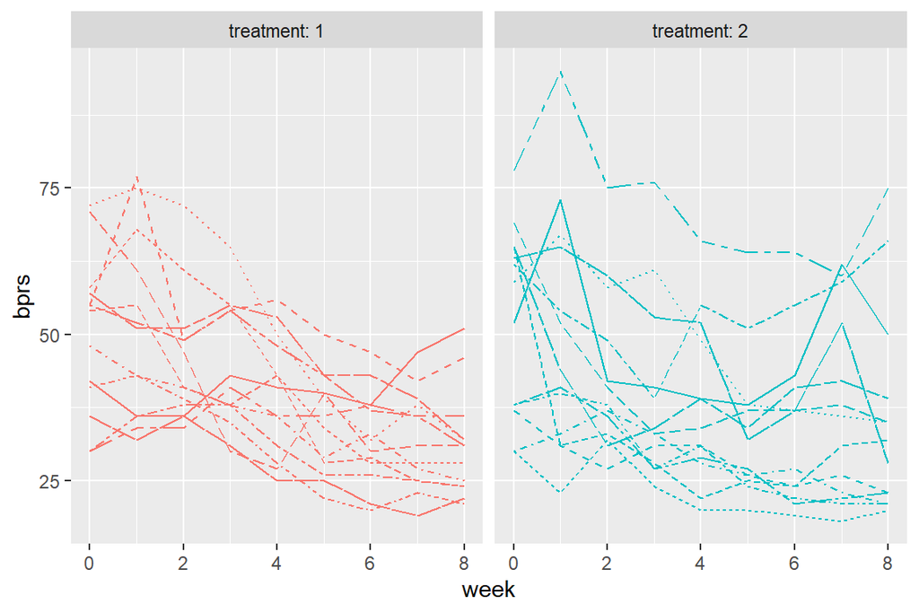

```r
# plot to explore the data
bprs %>% ggplot(aes(x = week, y = bprs, color = treatment)) +
  geom_line(aes(linetype = subject)) +
  facet_grid(. ~ treatment, labeller = label_both) +
  theme(legend.position = "none")
```

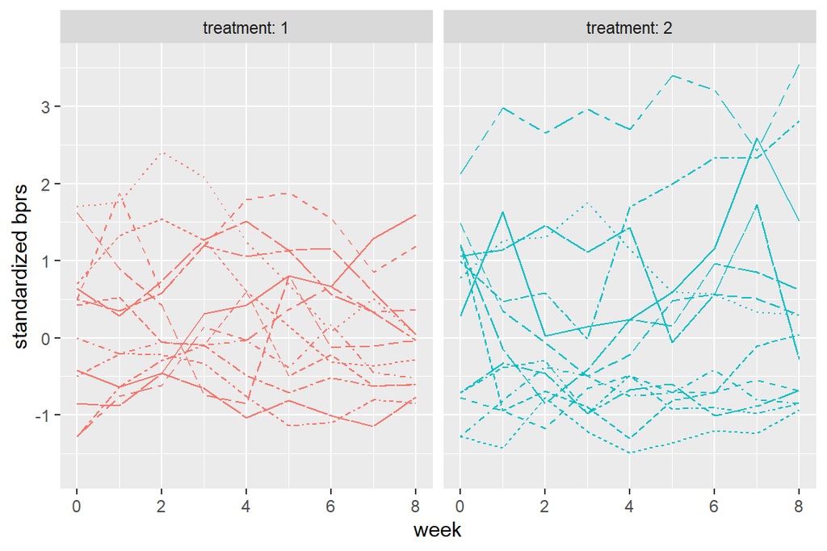

```r
# standardize the bprs variable
bprs <- bprs %>% group_by(week) %>% mutate(std_bprs = scale(bprs)) %>% ungroup()

# plot with standardized weight
bprs %>% ggplot(aes(x = week, y = std_bprs, color = treatment)) +
  geom_line(aes(linetype = subject)) +
  facet_grid(. ~ treatment, labeller = label_both) +
  theme(legend.position = "none") +
  scale_y_continuous(name = "standardized bprs")
```

I started by fitting a random intercet model on the data. The response variable is *bprs* and the explanatory variables are *week* and *treatment*. I have to stop the interpretation of my results here as I have to prioritize and other parts of my doctoral research are urgent at the moment. In short: The random intercept and random slope model is better than just the random intercept model. And the model with interaction term is not better than the random intercept and slope model.

```r
# fit a random intercept model
bprs_rim <- lmer(bprs ~ week + treatment + (1 | subject), data = bprs, REML = FALSE)

# summary of the random intercept model
summary(bprs_rim)
```

```
## Linear mixed model fit by maximum likelihood  ['lmerMod']
## Formula: bprs ~ week + treatment + (1 | subject)
##    Data: bprs
##
##      AIC      BIC   logLik deviance df.resid
##   2748.7   2768.1  -1369.4   2738.7      355
##
## Scaled residuals:
##     Min      1Q  Median      3Q     Max
## -3.0481 -0.6749 -0.1361  0.4813  3.4855
##
## Random effects:
##  Groups   Name        Variance Std.Dev.
##  subject  (Intercept)  47.41    6.885
##  Residual             104.21   10.208
## Number of obs: 360, groups:  subject, 20
##
## Fixed effects:
##             Estimate Std. Error t value
## (Intercept)  46.4539     1.9090  24.334
## week         -2.2704     0.2084 -10.896
## treatment2    0.5722     1.0761   0.532
##
## Correlation of Fixed Effects:
##            (Intr) week
## week       -0.437
## treatment2 -0.282  0.000
```

```r
# create a random intercept and random slope model
bprs_rim_rsm <- lmer(bprs ~ week + treatment + (week | subject), data = bprs, REML = FALSE)

# print a summary of the model
summary(bprs_rim_rsm)
```

```
## Linear mixed model fit by maximum likelihood  ['lmerMod']
## Formula: bprs ~ week + treatment + (week | subject)
##    Data: bprs
##
##      AIC      BIC   logLik deviance df.resid
##   2745.4   2772.6  -1365.7   2731.4      353
##
## Scaled residuals:
##     Min      1Q  Median      3Q     Max
## -2.8919 -0.6194 -0.0691  0.5531  3.7976
##
## Random effects:
##  Groups   Name        Variance Std.Dev. Corr
##  subject  (Intercept) 64.8222  8.0512
##           week         0.9609  0.9802   -0.51
##  Residual             97.4305  9.8707
## Number of obs: 360, groups:  subject, 20
##
## Fixed effects:
##             Estimate Std. Error t value
## (Intercept)  46.4539     2.1052  22.066
## week         -2.2704     0.2977  -7.626
## treatment2    0.5722     1.0405   0.550
##
## Correlation of Fixed Effects:
##            (Intr) week
## week       -0.582
## treatment2 -0.247  0.000
```

```r
# perform an ANOVA test on the two models
anova(bprs_rim_rsm, bprs_rim)
```

```
## Data: bprs
## Models:
## bprs_rim: bprs ~ week + treatment + (1 | subject)
## bprs_rim_rsm: bprs ~ week + treatment + (week | subject)
##              npar    AIC    BIC  logLik deviance  Chisq Df Pr(>Chisq)
## bprs_rim        5 2748.7 2768.1 -1369.4   2738.7
## bprs_rim_rsm    7 2745.4 2772.6 -1365.7   2731.4 7.2721  2    0.02636 *
## ---
## Signif. codes:  0 '***' 0.001 '**' 0.01 '*' 0.05 '.' 0.1 ' ' 1
```

```r
# create a random intercept and random slope model with the interaction
bprs_inter <- lmer(bprs ~ week + treatment + (week | subject) + week * treatment, data = bprs, REML = FALSE)

# print a summary of the model
summary(bprs_inter)
```

```
## Linear mixed model fit by maximum likelihood  ['lmerMod']
## Formula: bprs ~ week + treatment + (week | subject) + week * treatment
##    Data: bprs
##
##      AIC      BIC   logLik deviance df.resid
##   2744.3   2775.4  -1364.1   2728.3      352
##
## Scaled residuals:
##     Min      1Q  Median      3Q     Max
## -3.0512 -0.6271 -0.0768  0.5288  3.9260
##
## Random effects:
##  Groups   Name        Variance Std.Dev. Corr
##  subject  (Intercept) 64.9964  8.0620
##           week         0.9687  0.9842   -0.51
##  Residual             96.4707  9.8220
## Number of obs: 360, groups:  subject, 20
##
## Fixed effects:
##                 Estimate Std. Error t value
## (Intercept)      47.8856     2.2521  21.262
## week             -2.6283     0.3589  -7.323
## treatment2       -2.2911     1.9090  -1.200
## week:treatment2   0.7158     0.4010   1.785
##
## Correlation of Fixed Effects:
##             (Intr) week   trtmn2
## week        -0.650
## treatment2  -0.424  0.469
## wek:trtmnt2  0.356 -0.559 -0.840
```

```r
# perform an ANOVA test on the two models
anova(bprs_inter, bprs_rim_rsm)
```

```
## Data: bprs
## Models:
## bprs_rim_rsm: bprs ~ week + treatment + (week | subject)
## bprs_inter: bprs ~ week + treatment + (week | subject) + week * treatment
##              npar    AIC    BIC  logLik deviance  Chisq Df Pr(>Chisq)
## bprs_rim_rsm    7 2745.4 2772.6 -1365.7   2731.4
## bprs_inter      8 2744.3 2775.4 -1364.1   2728.3 3.1712  1    0.07495 .
## ---
## Signif. codes:  0 '***' 0.001 '**' 0.01 '*' 0.05 '.' 0.1 ' ' 1
```

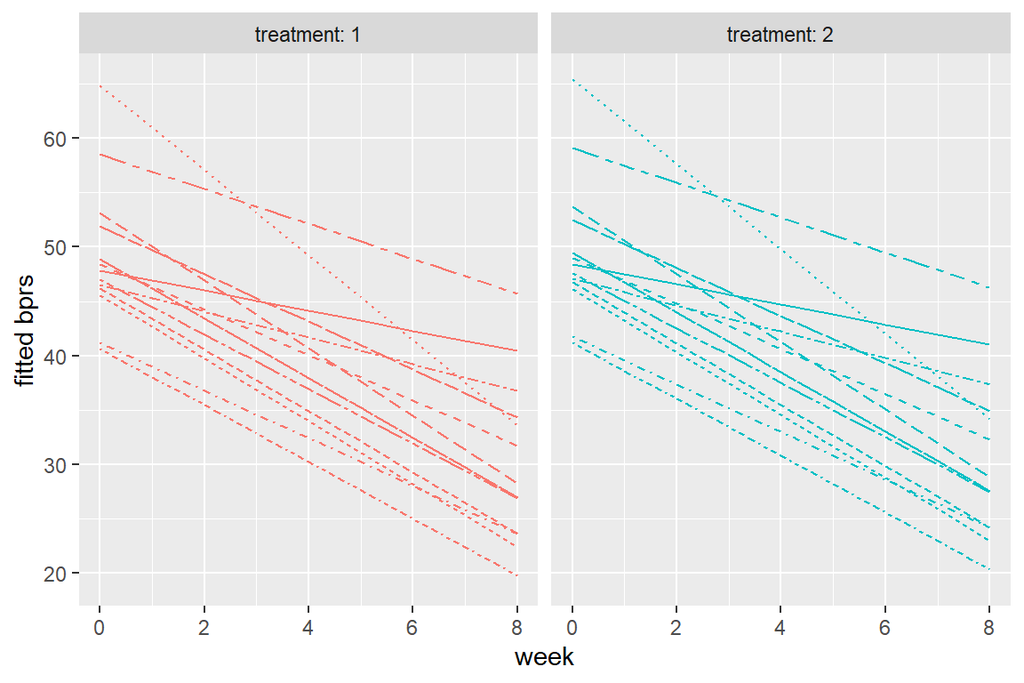

```r
# add fitted values to data
bprs$fitted <- fitted(bprs_rim_rsm)

# plot fitted values of bprs
bprs %>% ggplot(aes(x = week, y = fitted, color = treatment)) +
  geom_line(aes(linetype = subject)) +
  facet_grid(. ~ treatment, labeller = label_both) +
  theme(legend.position = "none") +
  scale_y_continuous(name = "fitted bprs")
```

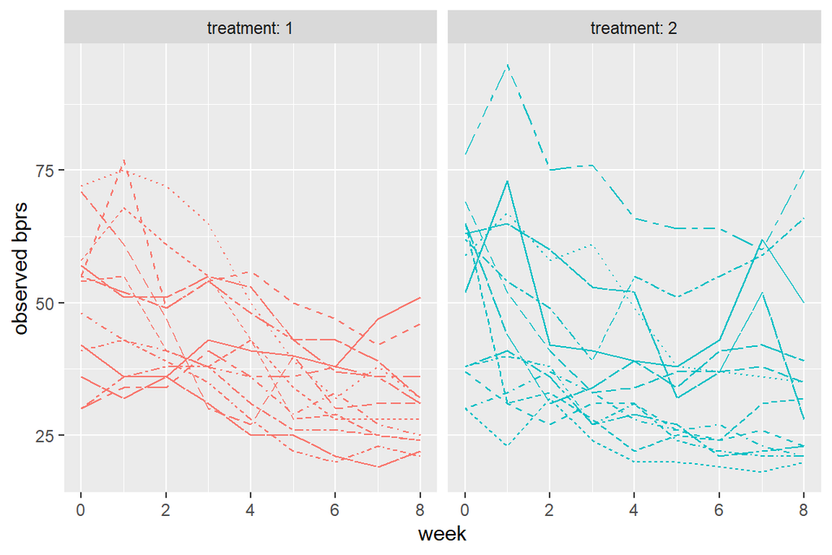

```r
# compare to original plot with observed bprs
bprs %>% ggplot(aes(x = week, y = bprs, color = treatment)) +
  geom_line(aes(linetype = subject)) +
  facet_grid(. ~ treatment, labeller = label_both) +
  theme(legend.position = "none") +
  scale_y_continuous(name = "observed bprs")
```

```r
date()
```

```
## [1] "Fri Dec 04 02:28:05 2020"
```